# Bookbinders: Customer Analysis & Statistical Testing

## 11. Add the predicted probabilities from the logistic regression to the bbb dataframe. Then report histograms of the predicted probabilities separately for each value of `do_it`. Comment on whether the results are consistent with the results of the partial dependence plots from Question 10.

Hint: To accomplish this, recall facet_wrap() from the R tutorial “the R tutorial.” You may want to use “scales=‘free_y’” within facet_wrap() * because relatively few people bought a larger number of do-it-yourself books. [* or aes(y=..density..) within geom_histogram()]

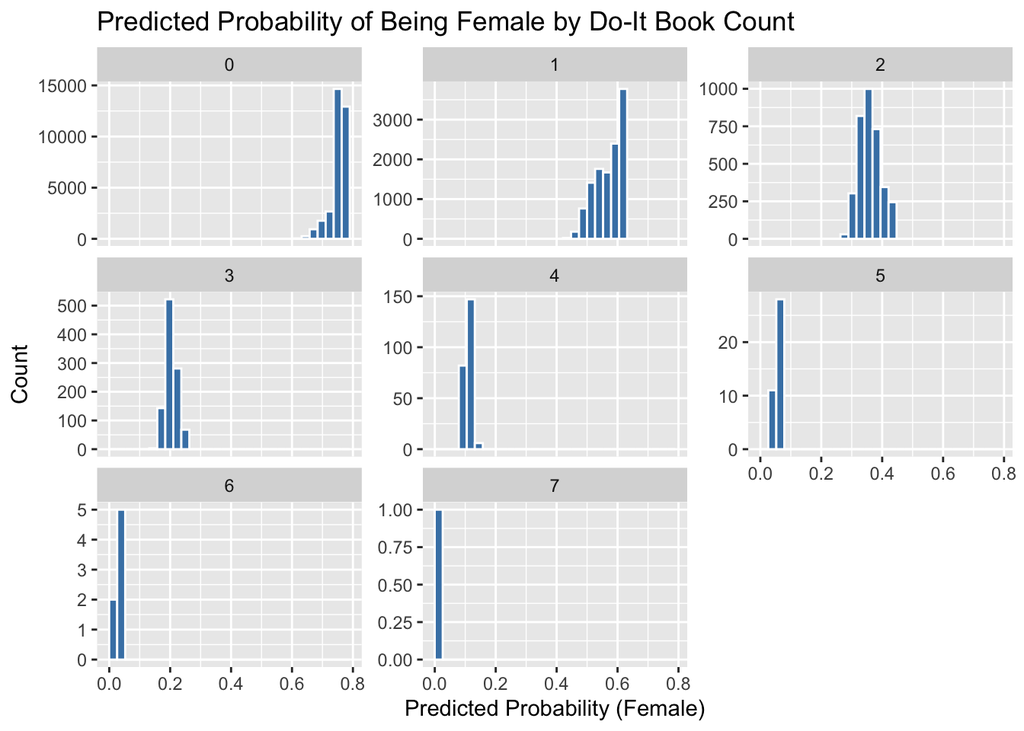

```r
# Add predicted probabilities (of being female) to the dataset
bbb$predicted_prob <- predict(log_model, type = "response")

library(ggplot2)

ggplot(bbb, aes(x = predicted_prob)) +
  geom_histogram(bins = 30, fill = "steelblue", color = "white") +
  facet_wrap(~ do_it, scales = "free_y") +
  labs(
    title = "Predicted Probability of Being Female by Do-It Book Count",
    x = "Predicted Probability (Female)",
    y = "Count"
  )
```

```r
#Top-left panel:This group is huge and most customers bought no DIY books.
#Predicted probabilities are clustered around 0.6–0.8, meaning,
#these customers are much more likely to be female.
#Distribution shifts gradually leftward as do_it increases.
#For do_it = 3, most probabilities are around 0.2–0.3.
#As customers buy more DIY books,model becomes less confident of being female
#this is consistent with partial dependence plot in Q10
```

## 12. Report histograms of `total` separately for each value of `do_it`. Does this plot help explain consistency or inconsistency discussed in Question 10?

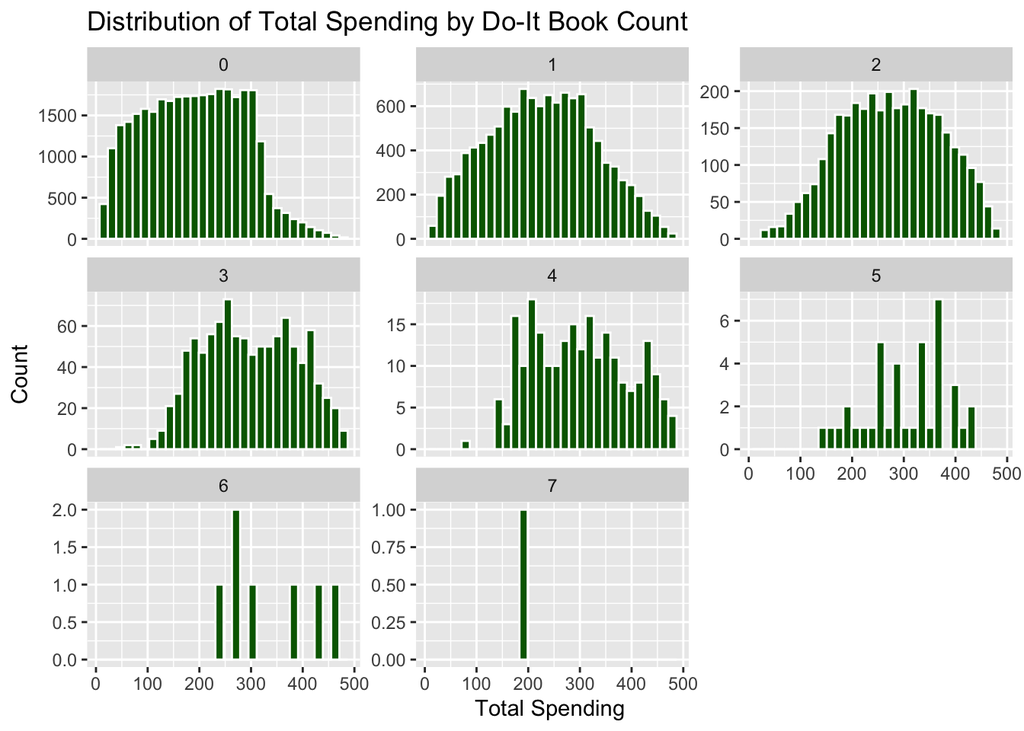

```r
library(ggplot2)

ggplot(bbb, aes(x = total)) +
  geom_histogram(bins = 30, fill = "darkgreen", color = "white") +
  facet_wrap(~ do_it, scales = "free_y") +
  labs(
    title = "Distribution of Total Spending by Do-It Book Count",
    x = "Total Spending",
    y = "Count"
  )
```

```r
# The histogram shows that total spending overlaps substantially across all levels of
#`do_it`.
# While higher `do_it` values are associated with somewhat higher spending ranges,
# customers with low `do_it` also span a wide range of total spending.
# Additionally, the number of customers decreases dramatically as `do_it` increases.
# This overlap explains why `total` is a poor predictor of gender in the logistic regression,
# even though `do_it` is a strong one.
# This pattern is consistent with the partial dependence plots in Q10:
# the PDP for `do_it` showed a steep drop in probability of being female,
# while the PDP for `total` showed only a shallow increase.
# Therefore, the results here support and help explain the findings in Q10.
```